# Dimension reduction influence on classification

Rafał Łobacz

2021-01-17

# Introduction

In this article I would like to check how dimension reduction influence data classification, by examining how prediction accuracy and model computing time differ before and after applying Principal Component Analysis (PCA). Research will be conducted on colorectal cancer data from Curated Microarray Database (CuMiDa). Article is divided into 2 parts. First part is about exploratory data analysis, where mostly I will use PCA to examine the data. Second part is about fitting and predicting 5 types of models – CLARA, Kmeans, Hierarchical Clustering, SVM and Random Forest. First 3 methods are unsupervised learning, clustering algorithms, where SVM and Random Forest are supervised methods, widely used in many fields that produce very often good results.

# Exploratory Data Analysis

Reading libraries

```r
library(data.table)
library(randomForest)
library(factoextra)
library(e1071)
library(flexclust)
library(tidyverse)
library(class)
library(clusterSim)
library(gridExtra)
library(ggplot2)
library(knitr)
```

Let`s read the data and check dimensionality.

```r
df <- fread('Colorectal_GSE44076.csv')
dim(df)
```

```
## [1]   194 49388
```

As we can see there are 194 rows and 49388 columns. It is not good that data have more columns than rows, but in our case we want to show how pca affect classification, the more columns to reduce the better. Let`s summarise first 6 columns and check how some part of the data looks.

```r
summary(df[,1:6]) %>% kable()
```

|  | samples | type | 11715100_at | 11715101_s_at | 11715102_x_at | 11715103_x_at |
| --- | --- | --- | --- | --- | --- | --- |
|  | Min. :648.0 | Length:194 | Min. :2.313 | Min. :3.035 | Min. :2.399 | Min. :2.464 |
|  | 1st Qu.:696.2 | Class :character | 1st Qu.:3.019 | 1st Qu.:3.844 | 1st Qu.:3.096 | 1st Qu.:3.395 |
|  | Median :745.5 | Mode :character | Median :3.275 | Median :4.094 | Median :3.399 | Median :3.637 |
|  | Mean :745.3 | NA | Mean :3.402 | Mean :4.177 | Mean :3.479 | Mean :3.673 |
|  | 3rd Qu.:794.8 | NA | 3rd Qu.:3.601 | 3rd Qu.:4.419 | 3rd Qu.:3.682 | 3rd Qu.:3.846 |
|  | Max. :843.0 | NA | Max. :6.209 | Max. :6.033 | Max. :5.927 | Max. :5.434 |

As we can see first column ‘samples’ consist of unique values of data, ‘type’ column is the type of cancer and all other columns are numeric description of each cancer value. Let`s check the types of cancer.

```r
table(df$type)
```

```
##
## adenocarcinoma         normal
##             97             97
```

Perfect we got balanced data. There are 2 types of cancer: adenocarcinoma and normal. Let`s check if there are any missing values.

```r
sum(is.na(df))
```

```
## [1] 0
```

There are no missing values. Let`s try to explore our data using PCA. I will only use PCA because MDS algorithm is not optimized, it took too much time to finish and my patience ran out.

```r
PCA_1 <- prcomp(df[,3:ncol(df)],center=T,scale.=T)
summary(PCA_1)
```

```
## Importance of components:
##                            PC1      PC2      PC3      PC4      PC5      PC6
## Standard deviation     91.7704 63.77123 46.81270 38.00408 34.51319 33.08278
## Proportion of Variance  0.1705  0.08235  0.04437  0.02925  0.02412  0.02216
## Cumulative Proportion   0.1705  0.25288  0.29725  0.32650  0.35062  0.37278
##                             PC7      PC8      PC9     PC10     PC11     PC12
## Standard deviation     28.59703 26.66069 24.98316 23.57632 23.07820 22.36457
## Proportion of Variance  0.01656  0.01439  0.01264  0.01126  0.01078  0.01013
## Cumulative Proportion   0.38934  0.40373  0.41637  0.42762  0.43841  0.44853
##                            PC13     PC14     PC15     PC16     PC17     PC18
## Standard deviation     21.48093 21.34849 21.26635 20.27821 20.13703 19.80963
## Proportion of Variance  0.00934  0.00923  0.00916  0.00833  0.00821  0.00795
## Cumulative Proportion   0.45788  0.46711  0.47626  0.48459  0.49280  0.50075
##                            PC19     PC20     PC21     PC22     PC23     PC24
## Standard deviation     19.54459 19.07579 18.82829 18.43063 18.36135 17.87679
## Proportion of Variance  0.00773  0.00737  0.00718  0.00688  0.00683  0.00647
## Cumulative Proportion   0.50848  0.51585  0.52303  0.52991  0.53673  0.54320
##                            PC25     PC26     PC27     PC28     PC29     PC30
## Standard deviation     17.59914 17.39874 17.15669 16.99220 16.83658 16.68297
## Proportion of Variance  0.00627  0.00613  0.00596  0.00585  0.00574  0.00564
## Cumulative Proportion   0.54948  0.55561  0.56157  0.56741  0.57315  0.57879
##                            PC31     PC32     PC33     PC34     PC35     PC36
## Standard deviation     16.36424 16.30358 16.12459 15.72515 15.54645 15.34963
## Proportion of Variance  0.00542  0.00538  0.00526  0.00501  0.00489  0.00477
## Cumulative Proportion   0.58421  0.58959  0.59486  0.59986  0.60476  0.60953
##                            PC37     PC38     PC39     PC40     PC41     PC42
## Standard deviation     15.30302 15.25968 15.10636 14.88174 14.79385 14.65756
## Proportion of Variance  0.00474  0.00472  0.00462  0.00448  0.00443  0.00435
## Cumulative Proportion   0.61427  0.61899  0.62361  0.62809  0.63252  0.63687
##                            PC43     PC44     PC45     PC46     PC47     PC48
## Standard deviation     14.49396 14.43754 14.31665 14.15628 14.12032 13.90618
## Proportion of Variance  0.00425  0.00422  0.00415  0.00406  0.00404  0.00392
## Cumulative Proportion   0.64113  0.64535  0.64950  0.65356  0.65759  0.66151
##                           PC49     PC50     PC51     PC52     PC53    PC54
## Standard deviation     13.8780 13.72412 13.66710 13.62382 13.54581 13.5249
## Proportion of Variance  0.0039  0.00381  0.00378  0.00376  0.00372  0.0037
## Cumulative Proportion   0.6654  0.66922  0.67300  0.67676  0.68048  0.6842
##                            PC55     PC56     PC57     PC58     PC59     PC60
## Standard deviation     13.36582 13.29106 13.26145 13.16918 13.10496 13.03122
## Proportion of Variance  0.00362  0.00358  0.00356  0.00351  0.00348  0.00344
```

[output cut: 70 more lines]

```
## Standard deviation     9.19762 9.18027 9.14574 9.12728 9.10385 9.08359 9.05714
## Proportion of Variance 0.00171 0.00171 0.00169 0.00169 0.00168 0.00167 0.00166
## Cumulative Proportion  0.95992 0.96163 0.96332 0.96501 0.96668 0.96835 0.97002
##                          PC174   PC175   PC176   PC177   PC178   PC179   PC180
## Standard deviation     9.01972 9.00658 8.95894 8.93468 8.86708 8.81541 8.78986
## Proportion of Variance 0.00165 0.00164 0.00163 0.00162 0.00159 0.00157 0.00156
## Cumulative Proportion  0.97166 0.97331 0.97493 0.97655 0.97814 0.97971 0.98128
##                          PC181   PC182   PC183   PC184  PC185   PC186   PC187
## Standard deviation     8.78160 8.72457 8.69236 8.67873 8.6209 8.54715 8.50667
## Proportion of Variance 0.00156 0.00154 0.00153 0.00153 0.0015 0.00148 0.00147
## Cumulative Proportion  0.98284 0.98438 0.98591 0.98744 0.9889 0.99042 0.99188
##                          PC188  PC189   PC190   PC191   PC192   PC193     PC194
## Standard deviation     8.43597 8.3068 8.28179 8.19358 7.96104 7.84308 1.753e-13
## Proportion of Variance 0.00144 0.0014 0.00139 0.00136 0.00128 0.00125 0.000e+00
## Cumulative Proportion  0.99333 0.9947 0.99611 0.99747 0.99875 1.00000 1.000e+00
```

When we perform PCA and data got more columns than rows, the maximum number of PCs produced is the number of rows. As we can see 194 PCs were produced and first 2 PCs explain only 25% of variance. Normally it would not be good, but when we consider that initiall data got 49388 columns, it is not that bad. Let`s visualise PCA by rows and columns.

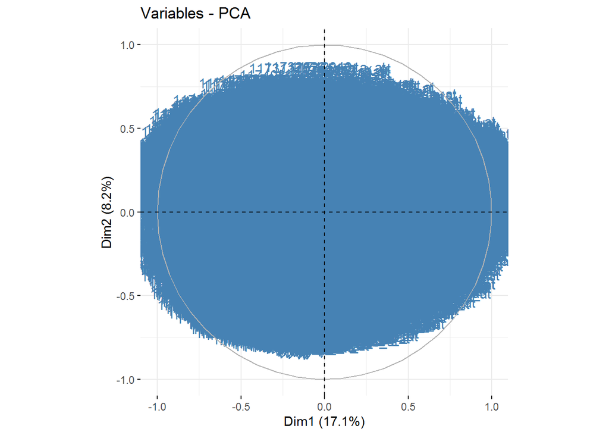

```r
fviz_pca_var(PCA_1,col.var = 'steelblue' )
```

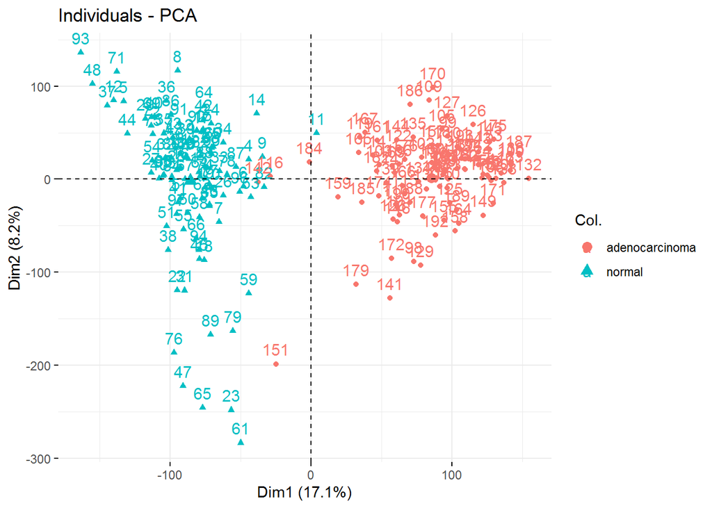

```r
fviz_pca_ind(PCA_1,col.ind = df$type)
```

We can not say too much about first plot, there are many variables all over the plot. Looking at second plot we can clearly see 2 groups of cancer. We can easily distinguish them just from 2 dimension that explain 25% of data. There are like 5 controversial points that algorithms can have problems. Even though I am expecting >95% accuracy of classification just looking at this plot. Let`s draw some scree plots now.

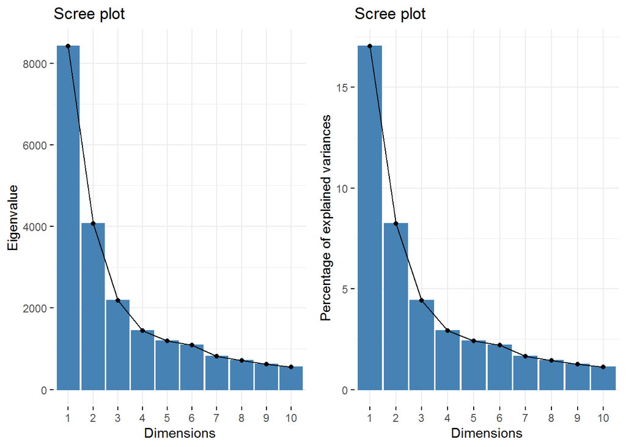

```r
p_1 <- fviz_eig(PCA_1, choice='eigenvalue')
p_2 <- fviz_eig(PCA_1)
grid.arrange(p_1,p_2,ncol=2)
```

From the first plot we can see that PCs got very high eigenvalues that drop exponentially, from the second plot we can see that after 6 dimensions variance explained is very small. Let`s now plot the cumulative variance plot.

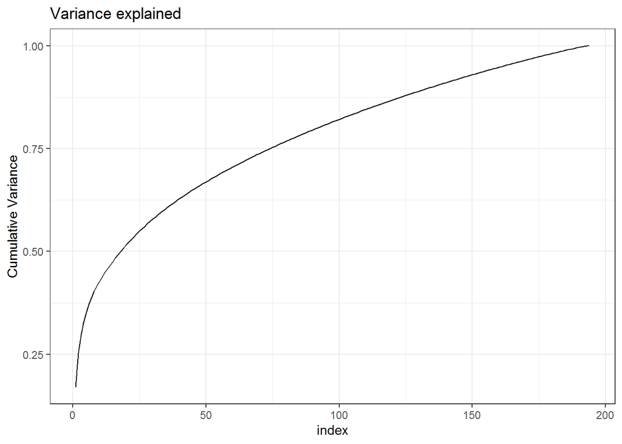

```r
ggplot() + geom_line(aes(x=1:194,y=summary(PCA_1)$importance[3,])) +
  labs(y="Cumulative Variance", x="index",title="Variance explained") + theme_bw()
```

Plot is very unusual, most of the dimensions explain very small percentage of variance. Only first few PCs up to ~45% of cumulative variance explain some significant part of data.

```r
eig.val<-get_eigenvalue(PCA_1)
eig.val
```

```
##           eigenvalue variance.percent cumulative.variance.percent
## Dim.1   8.421804e+03     1.705302e+01                    17.05302
## Dim.2   4.066770e+03     8.234661e+00                    25.28768
## Dim.3   2.191429e+03     4.437348e+00                    29.72503
## Dim.4   1.444310e+03     2.924534e+00                    32.64956
## Dim.5   1.191161e+03     2.411940e+00                    35.06150
## Dim.6   1.094471e+03     2.216156e+00                    37.27766
## Dim.7   8.177902e+02     1.655915e+00                    38.93357
## Dim.8   7.107925e+02     1.439259e+00                    40.37283
## Dim.9   6.241581e+02     1.263836e+00                    41.63667
## Dim.10  5.558430e+02     1.125507e+00                    42.76217
## Dim.11  5.326034e+02     1.078450e+00                    43.84062
## Dim.12  5.001742e+02     1.012785e+00                    44.85341
## Dim.13  4.614303e+02     9.343343e-01                    45.78774
## Dim.14  4.557580e+02     9.228486e-01                    46.71059
## Dim.15  4.522577e+02     9.157610e-01                    47.62635
## Dim.16  4.112057e+02     8.326361e-01                    48.45899
## Dim.17  4.055001e+02     8.210832e-01                    49.28007
## Dim.18  3.924214e+02     7.946004e-01                    50.07467
## Dim.19  3.819912e+02     7.734807e-01                    50.84815
## Dim.20  3.638859e+02     7.368200e-01                    51.58497
## Dim.21  3.545045e+02     7.178240e-01                    52.30280
## Dim.22  3.396883e+02     6.878230e-01                    52.99062
## Dim.23  3.371393e+02     6.826616e-01                    53.67328
## Dim.24  3.195798e+02     6.471060e-01                    54.32039
## Dim.25  3.097296e+02     6.271607e-01                    54.94755
## Dim.26  3.027162e+02     6.129595e-01                    55.56051
## Dim.27  2.943521e+02     5.960233e-01                    56.15653
## Dim.28  2.887350e+02     5.846495e-01                    56.74118
## Dim.29  2.834705e+02     5.739896e-01                    57.31517
## Dim.30  2.783215e+02     5.635636e-01                    57.87873
## Dim.31  2.677882e+02     5.422351e-01                    58.42097
## Dim.32  2.658066e+02     5.382226e-01                    58.95919
## Dim.33  2.600025e+02     5.264701e-01                    59.48566
## Dim.34  2.472805e+02     5.007097e-01                    59.98637
## Dim.35  2.416921e+02     4.893940e-01                    60.47577
## Dim.36  2.356111e+02     4.770807e-01                    60.95285
## Dim.37  2.341826e+02     4.741882e-01                    61.42704
## Dim.38  2.328577e+02     4.715055e-01                    61.89854
## Dim.39  2.282022e+02     4.620787e-01                    62.36062
```

[output cut: 140 more lines]

```
## Dim.180 7.726159e+01     1.564443e-01                    98.12774
## Dim.181 7.711649e+01     1.561505e-01                    98.28389
## Dim.182 7.611813e+01     1.541290e-01                    98.43802
## Dim.183 7.555704e+01     1.529928e-01                    98.59102
## Dim.184 7.532035e+01     1.525136e-01                    98.74353
## Dim.185 7.432012e+01     1.504882e-01                    98.89402
## Dim.186 7.305381e+01     1.479241e-01                    99.04194
## Dim.187 7.236339e+01     1.465261e-01                    99.18847
## Dim.188 7.116562e+01     1.441008e-01                    99.33257
## Dim.189 6.900235e+01     1.397205e-01                    99.47229
## Dim.190 6.858803e+01     1.388815e-01                    99.61117
## Dim.191 6.713481e+01     1.359390e-01                    99.74711
## Dim.192 6.337820e+01     1.283323e-01                    99.87544
## Dim.193 6.151393e+01     1.245574e-01                   100.00000
## Dim.194 3.072873e-26     6.222155e-29                   100.00000
```

I decided that I will use only those PCs that explain more than 1% of variance.

# Classification

## Data preparation - splitting data to train and test

Our data is balanced, so we will take 15 random samples from each type of cancer as the test data. The best approach would be to perform k-fold cross validation but with 5 types of models it could take too much time.

```r
set.seed(123)
df %>% dplyr::select(samples,type) %>% filter(type=='adenocarcinoma') %>% pull(samples) %>%
  sample(15) ->t_1

df %>% dplyr::select(samples,type) %>% filter(type=='normal') %>% pull(samples) %>%
  sample(15) ->t_2

train <- df %>% filter(!samples %in% c(t_1,t_2))
test <- df %>% filter(samples %in% c(t_1,t_2))

train_X <- train %>% dplyr::select(-samples,-type)
train_Y <- train %>% dplyr::select(type)
test_X <- test %>% dplyr::select(-samples,-type)
test_Y <- test %>% dplyr::select(type)
```

Let`s perform also PCA on data and visualise which sample was taken as test data. As I said previously I will take only PCs with Variance explained greater than 1%. It turned out to be first 12 PCs

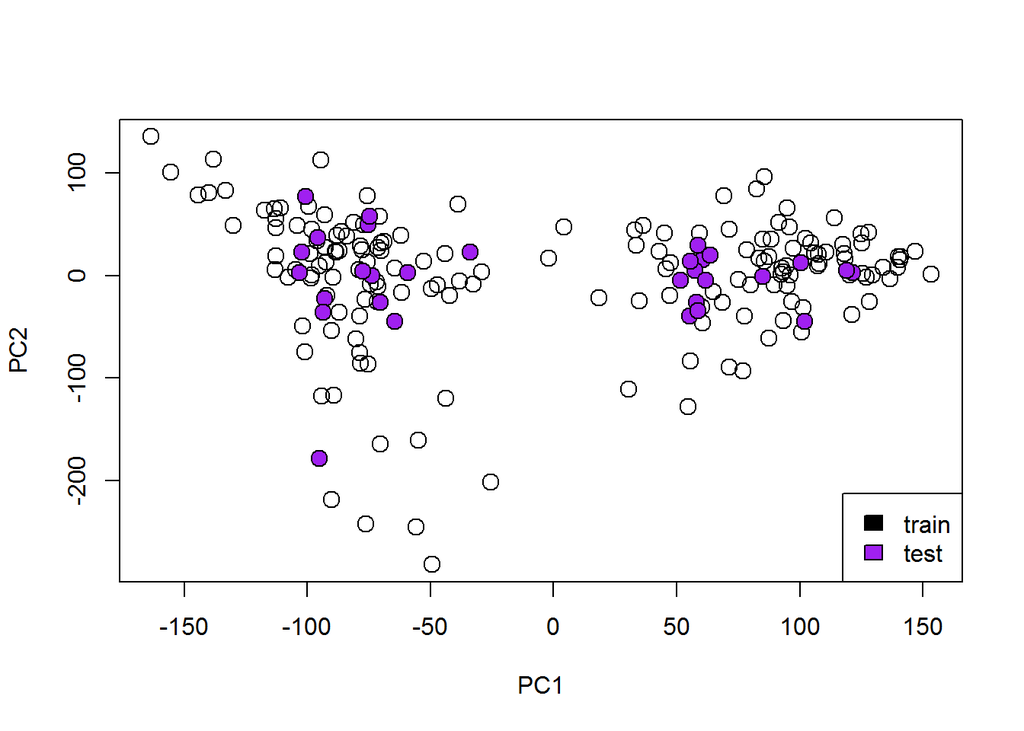

```r
X_PCA<-prcomp(train_X,center=T,scale.=T)
test_X_N <- predict(X_PCA,test_X)
train_X_N <- X_PCA$x[,1:12]
test_X_N <- test_X_N[,1:12]

plot(train_X_N[,1:2],col='black',cex=1.5)
points(test_X_N[,1:2],pch=21,bg="purple",cex=1.5)
legend('bottomright',legend=c('train','test'),fill=c('black','purple'))
```

As we can see on the plot almost all test data are in the center of groups. Most of the algorithms will probably have no problem classifying them. Now I will create matrices to store computing time and accuracy values.

```r
df_acc <- data.frame( train_test = character(), CLARA=numeric(),CLARA_PCA=numeric(),
                     KMEANS=numeric(),KMEANS_PCA=numeric(),
                     HCLUST=numeric(),HCLUST_PCA=numeric(),SVM=numeric(),SVM_PCA=numeric(),
                     RF=numeric(),RF_PCA=numeric())
df_acc[1:2,2:11] <- 0
df_acc$train_test <- c('train','test')

#creating matrix to store time computing
df_time <- data.frame( CLARA=numeric(),CLARA_PCA=numeric(),
                      KMEANS=numeric(),KMEANS_PCA=numeric(),
                      HCLUST=numeric(),HCLUST_PCA=numeric(),SVM=numeric(),SVM_PCA=numeric(),
                      RF=numeric(),RF_PCA=numeric())
df_time[1,1:10] <- 0
rownames(df_time) <- 'train_time'
```

## Perfoming classification

First 3 algorithms that will be used are clustering methods. They group objects in a way that in the same group(cluster) observations are more similar to each other than to those in other groups. First method - CLARA(Clustering Large Applications) is an extension to k-medoids (PAM) methods to deal with data containing a large number of objects in order to reduce computing time. This is achieved using the sampling approach. Next method is k-means. This is the most popular clustering method that partition observations to k clusters in which observations belong to the cluster with the nearest mean (centroid). The last clustering method is hclust - hierarchical clustering that seeks to build a hierarchy of clusters. Other two methods are supervised algorithms. Support Vector Machines(SVM) uses linear or non-linear classifier that separates the space, into two or more regions that are called classes. Random forest is an ensemble method that trains several decision trees in parallel with bootstrapping followed by aggregation. Now I am going to perform each model on raw data and dimension reduced data.

### Classifications on raw data

#### Clara

Training

```r
ptm_1 <- proc.time()
clara_train <- eclust(train_X,"clara", hc_metric="euclidean",k=2,graph=F)
t_1 <- proc.time() - ptm_1
table_1 <- table(clara_train$cluster,train_Y$type)
table_1
```

```
##
##     adenocarcinoma normal
##   1              6     82
##   2             76      0
```

```r
score_clara_train <- sum(apply(table_1, 2, max))/164
df_acc[1,"CLARA"] <- round(score_clara_train*100,2)
df_time[1] <- t_1[3]
paste('Accuracy on training data:', score_clara_train)
```

```
## [1] "Accuracy on training data: 0.963414634146341"
```

```r
paste('Model trained in:' , t_1[3] ,' sec.')
```

```
## [1] "Model trained in: 29.97  sec."
```

Test

```r
clara_test_kcca<-as.kcca(clara_train, train_X)
clara_pred<-predict(clara_test_kcca, test_X)
table_11 <- table(clara_pred,test_Y$type)
table_11
```

```
##
## clara_pred adenocarcinoma normal
##          1              0     15
##          2             15      0
```

```r
score_clara_test <- sum(apply(table_11, 2, max))/30
df_acc[2,"CLARA"] <- round(score_clara_test*100,2)
paste('Accuracy on test data:', score_clara_test)
```

```
## [1] "Accuracy on test data: 1"
```

#### Kmeans

Training

```r
ptm_2 <- proc.time()
kmeans_train <- eclust(train_X,"kmeans", hc_metric="euclidean",k=2,graph=F)
t_2 <- proc.time() - ptm_2
table_2 <- table(kmeans_train$cluster,train_Y$type)
table_2
```

```
##
##     adenocarcinoma normal
##   1             80      0
##   2              2     82
```

```r
score_kmeans_train <- sum(apply(table_2, 2, max))/164
df_acc[1,"KMEANS"] <- round(score_kmeans_train*100,2)
df_time[3] <- t_2[3]
paste('Accuracy on training data:', score_kmeans_train)
```

```
## [1] "Accuracy on training data: 0.98780487804878"
```

```r
paste('Model trained in:' , t_2[3] ,' sec.')
```

```
## [1] "Model trained in: 24.27  sec."
```

Test

```r
kmeans_test_kcca<-as.kcca(kmeans_train, train_X)
kmeans_pred<-predict(kmeans_test_kcca, test_X)
table_21 <- table(kmeans_pred,test_Y$type)
table_21
```

```
##
## kmeans_pred adenocarcinoma normal
##           1             15      0
##           2              0     15
```

```r
kmeans_clara_test <- sum(apply(table_21, 2, max))/30
df_acc[2,"KMEANS"] <- round(kmeans_clara_test*100,2)
paste('Accuracy on test data:', kmeans_clara_test)
```

```
## [1] "Accuracy on test data: 1"
```

#### Hclust

Training

```r
ptm_3 <- proc.time()
hclust_train <- eclust(train_X,"hclust", hc_metric="euclidean",k=2,graph=F)
t_3 <- proc.time() - ptm_3
table_3 <- table(hclust_train$cluster,train_Y$type)
table_3
```

```
##
##     adenocarcinoma normal
##   1              1     80
##   2             81      2
```

```r
score_hclust_train <- sum(apply(table_3, 2, max))/164
df_acc[1,"HCLUST"] <- round(score_hclust_train*100,2)
df_time[5] <- t_3[3]
paste('Accuracy on training data:', score_hclust_train)
```

```
## [1] "Accuracy on training data: 0.981707317073171"
```

```r
paste('Model trained in:' , t_3[3] ,' sec.')
```

```
## [1] "Model trained in: 29.19  sec."
```

Test

```r
groups<-cutree(hclust_train,k=2)
hclust_pred<-knn(train_X, test_X,k=1,cl=groups)
table_31 <- table(hclust_pred,test_Y$type)
table_31
```

```
##
## hclust_pred adenocarcinoma normal
##           1              0     15
##           2             15      0
```

```r
kmeans_hclust_test <- sum(apply(table_31, 2, max))/30
df_acc[2,"HCLUST"] <- round(kmeans_hclust_test*100,2)
paste('Accuracy on test data:', kmeans_hclust_test)
```

```
## [1] "Accuracy on test data: 1"
```

#### SVM

Training

```r
ptm_4 <- proc.time()
model4 <- svm(x=train_X,y=factor(train_Y$type), kernel = "linear", scale = FALSE)
t_4 <- proc.time() - ptm_4
table_4 <- table(model4$fitted,train_Y$type)
table_4
```

```
##
##                  adenocarcinoma normal
##   adenocarcinoma             82      0
##   normal                      0     82
```

```r
svm_train <- sum(apply(table_4, 2, max))/164
df_acc[1,"SVM"] <- round(svm_train*100,2)
df_time[7] <- t_4[3]
paste('Accuracy on training data:', svm_train)
```

```
## [1] "Accuracy on training data: 1"
```

```r
paste('Model trained in:' , t_4[3] ,' sec.')
```

```
## [1] "Model trained in: 4.69  sec."
```

Test

```r
model4_predict <- predict(model4,test_X)
table_41 <- table(model4_predict,test_Y$type)
table_41
```

```
##
## model4_predict   adenocarcinoma normal
##   adenocarcinoma             15      0
##   normal                      0     15
```

```r
svm_test <- sum(apply(table_41, 2, max))/30
df_acc[2,"SVM"] <- round(svm_test*100,2)
paste('Accuracy on test data:', svm_test)
```

```
## [1] "Accuracy on test data: 1"
```

#### Random Forest

Training

```r
ptm_5 <- proc.time()
model5 <- randomForest(x=train_X,y=factor(train_Y$type))
t_5 <- proc.time() - ptm_5
table_5 <- table(model5$predicted,train_Y$type)
table_5
```

```
##
##                  adenocarcinoma normal
##   adenocarcinoma             79      1
##   normal                      3     81
```

```r
rf_train <- sum(apply(table_5, 2, max))/164
df_acc[1,"RF"] <- round(rf_train*100,2)
df_time[9] <- t_5[3]
paste('Accuracy on training data:', rf_train)
```

```
## [1] "Accuracy on training data: 0.975609756097561"
```

```r
paste('Model trained in:' , t_5[3] ,' sec.')
```

```
## [1] "Model trained in: 77.95  sec."
```

Test

```r
model5_predict <- predict(model5,test_X)
table_51 <- table(model5_predict,test_Y$type)
table_51
```

```
##
## model5_predict   adenocarcinoma normal
##   adenocarcinoma             15      0
##   normal                      0     15
```

```r
rf_test <- sum(apply(table_51, 2, max))/30
df_acc[2,"RF"] <- round(rf_test*100,2)
paste('Accuracy on test data:', rf_test)
```

```
## [1] "Accuracy on test data: 1"
```

### Classifications on PCA

#### Clara

Training

```r
ptm_6 <- proc.time()
clara_train_pca <- eclust(train_X_N,"clara", hc_metric="euclidean",k=2,graph = F)
t_6 <- proc.time() - ptm_6
table_1_pca <- table(clara_train_pca$cluster,train_Y$type)
table_1_pca
```

```
##
##     adenocarcinoma normal
##   1              3     81
##   2             79      1
```

```r
score_clara_train_pca <- sum(apply(table_1_pca, 2, max))/164
df_acc[1,"CLARA_PCA"] <- round(score_clara_train_pca*100,2)
df_time[2] <- t_6[3]
paste('Accuracy on test data:', score_clara_train_pca)
```

```
## [1] "Accuracy on test data: 0.975609756097561"
```

```r
paste('Model trained in:' , t_6[3] ,' sec.')
```

```
## [1] "Model trained in: 0.00999999999999091  sec."
```

Test

```r
clara_test_kcca_pca<-as.kcca(clara_train_pca, train_X_N)
clara_pred_pca<-predict(clara_test_kcca_pca, test_X_N)
table_11_pca <- table(clara_pred_pca,test_Y$type)
table_11_pca
```

```
##
## clara_pred_pca adenocarcinoma normal
##              1              0     15
##              2             15      0
```

```r
score_clara_test_pca <- sum(apply(table_11_pca, 2, max))/30
df_acc[2,"CLARA_PCA"] <- round(score_clara_test_pca*100,2)
paste('Accuracy on test data:', score_clara_test_pca)
```

```
## [1] "Accuracy on test data: 1"
```

#### Kmeans

Training

```r
ptm_7 <- proc.time()
kmeans_train_pca <- eclust(train_X_N,"kmeans", hc_metric="euclidean",k=2,graph=F)
t_7 <- proc.time() - ptm_7
table_2_pca <- table(kmeans_train_pca$cluster,train_Y$type)
table_2_pca
```

```
##
##     adenocarcinoma normal
##   1             78      0
##   2              4     82
```

```r
score_kmeans_train_pca <- sum(apply(table_2_pca, 2, max))/164
df_acc[1,"KMEANS_PCA"] <- round(score_kmeans_train_pca*100,2)
df_time[4] <- t_7[3]
paste('Accuracy on test data:', score_kmeans_train_pca)
```

```
## [1] "Accuracy on test data: 0.975609756097561"
```

```r
paste('Model trained in:' , t_7[3] ,' sec.')
```

```
## [1] "Model trained in: 0  sec."
```

Test

```r
kmeans_test_kcca_pca<-as.kcca(kmeans_train_pca, train_X_N)
kmeans_pred_pca<-predict(kmeans_test_kcca_pca, test_X_N)
table_21_pca <- table(kmeans_pred_pca,test_Y$type)
table_21_pca
```

```
##
## kmeans_pred_pca adenocarcinoma normal
##               1             15      0
##               2              0     15
```

```r
score_kmeans_test_pca <- sum(apply(table_21_pca, 2, max))/30
df_acc[2,"KMEANS_PCA"] <- round(score_kmeans_test_pca*100,2)
paste('Accuracy on test data:', score_kmeans_test_pca)
```

```
## [1] "Accuracy on test data: 1"
```

#### Hclust

Training

```r
ptm_8 <- proc.time()
hclust_train_pca <- eclust(train_X_N,"hclust", hc_metric="euclidean",k=2,graph=F)
t_8 <- proc.time() - ptm_8
table_3_pca <- table(hclust_train_pca$cluster,train_Y$type)
table_3_pca
```

```
##
##     adenocarcinoma normal
##   1              2     82
##   2             80      0
```

```r
score_hclust_train_pca <- sum(apply(table_3_pca, 2, max))/164
df_acc[1,"HCLUST_PCA"] <- round(score_hclust_train_pca*100,2)
df_time[6] <- t_8[3]
paste('Accuracy on test data:', score_hclust_train_pca)
```

```
## [1] "Accuracy on test data: 0.98780487804878"
```

```r
paste('Model trained in:' , t_8[3] ,' sec.')
```

```
## [1] "Model trained in: 0.0100000000000193  sec."
```

Test

```r
groups_N<-cutree(hclust_train_pca,k=2)
hclust_pred_N<-knn(train_X_N, test_X_N,k=1,cl=groups_N)
table_31_pca <- table(hclust_pred_N,test_Y$type)
table_31_pca
```

```
##
## hclust_pred_N adenocarcinoma normal
##             1              0     15
##             2             15      0
```

```r
score_hclust_test_PCA <- sum(apply(table_31_pca, 2, max))/30
df_acc[2,"HCLUST_PCA"] <- round(score_hclust_test_PCA*100,2)
paste('Accuracy on test data:', score_hclust_test_PCA)
```

```
## [1] "Accuracy on test data: 1"
```

#### SVM

Training

```r
ptm_9 <- proc.time()
model4_PCA <- svm(x=train_X_N,y=factor(train_Y$type), kernel = "linear", scale = FALSE)
t_9 <- proc.time() - ptm_9
table_4_PCA <- table(model4_PCA$fitted,train_Y$type)
table_4_PCA
```

```
##
##                  adenocarcinoma normal
##   adenocarcinoma             82      0
##   normal                      0     82
```

```r
svm_train_PCA <- sum(apply(table_4_PCA, 2, max))/164
df_acc[1,"SVM_PCA"] <- round(svm_train_PCA*100,2)
df_time[8] <- t_9[3]
paste('Accuracy on test data:', svm_train_PCA)
```

```
## [1] "Accuracy on test data: 1"
```

```r
paste('Model trained in:' , t_9[3] ,' sec.')
```

```
## [1] "Model trained in: 0  sec."
```

Test

```r
model4_predict_PCA <- predict(model4_PCA,test_X_N)
table_41_PCA <- table(model4_predict_PCA,test_Y$type)
table_41_PCA
```

```
##
## model4_predict_PCA adenocarcinoma normal
##     adenocarcinoma             15      0
##     normal                      0     15
```

```r
svm_test_PCA <- sum(apply(table_41_PCA, 2, max))/30
df_acc[2,"SVM_PCA"] <- round(svm_test_PCA*100,2)
paste('Accuracy on test data:', svm_test_PCA)
```

```
## [1] "Accuracy on test data: 1"
```

#### Random Forest

Training

```r
ptm_10 <- proc.time()
model5_PCA <- randomForest(x=train_X_N,y=factor(train_Y$type))
t_10 <- proc.time() - ptm_10
table_5_PCA <- table(model5_PCA$predicted,train_Y$type)
table_5_PCA
```

```
##
##                  adenocarcinoma normal
##   adenocarcinoma             81      1
##   normal                      1     81
```

```r
rf_train_PCA <- sum(apply(table_5_PCA, 2, max))/164
df_acc[1,"RF_PCA"] <- round(rf_train_PCA*100,2)
df_time[10] <- t_10[3]
paste('Accuracy on test data:', rf_train_PCA)
```

```
## [1] "Accuracy on test data: 0.98780487804878"
```

```r
paste('Model trained in:' , t_10[3] ,' sec.')
```

```
## [1] "Model trained in: 0.0499999999999829  sec."
```

Test

```r
model5_predict_PCA <- predict(model5_PCA,test_X_N)
table_51_PCA <- table(model5_predict_PCA,test_Y$type)
table_51_PCA
```

```
##
## model5_predict_PCA adenocarcinoma normal
##     adenocarcinoma             15      0
##     normal                      0     15
```

```r
rf_test_PCA <- sum(apply(table_51_PCA, 2, max))/30
df_acc[2,"RF_PCA"] <- round(rf_test_PCA*100,2)
paste('Accuracy on test data:', rf_test_PCA)
```

```
## [1] "Accuracy on test data: 1"
```

## Comparing classification on raw data vs PCA

Firstly let`s print table of computation times.

```r
df_time %>% kable()
```

|  | CLARA | CLARA_PCA | KMEANS | KMEANS_PCA | HCLUST | HCLUST_PCA | SVM | SVM_PCA | RF | RF_PCA |
| --- | --- | --- | --- | --- | --- | --- | --- | --- | --- | --- |
| train_time | 29.97 | 0.01 | 24.27 | 0 | 29.19 | 0.01 | 4.69 | 0 | 77.95 | 0.05 |

As we can see there is incredible difference between running time of algorithms on raw data vs on data after PCA. Let`s look at accuracy matrix now.

```r
df_acc %>% kable()
```

| train_test | CLARA | CLARA_PCA | KMEANS | KMEANS_PCA | HCLUST | HCLUST_PCA | SVM | SVM_PCA | RF | RF_PCA |
| --- | --- | --- | --- | --- | --- | --- | --- | --- | --- | --- |
| train | 96.34 | 97.56 | 98.78 | 97.56 | 98.17 | 98.78 | 100 | 100 | 97.56 | 98.78 |
| test | 100.00 | 100.00 | 100.00 | 100.00 | 100.00 | 100.00 | 100 | 100 | 100.00 | 100.00 |

We can see that accuracy even improved on PCA. Only Kmeans perform worse after PCA. This is great information, we did not have trade off between computing time and accuracy.

Summary

Goal of this paper was to check how dimension reduction with PCA influence data classification procedure. We can definitely see that running time of algorithms drops drastically. Although making statements about accuracy is tricky here. It seems like PCA does not have any negative influence on predictions and classifications. Yet metodology was not perfect here, k-fold cross validation should be performed. Data itself is not ordinary, there are more columns than rows. Moreover SVM seems to be the best classification method in comparison to other on used data.

Bibliography

https://stanford.edu/~cpiech/cs221/handouts/kmeans.html

https://www.datanovia.com/en/lessons/clara-in-r-clustering-large-applications/

https://www.rdocumentation.org/packages/stats/versions/3.6.2/topics/hclust

https://www.analyticsvidhya.com/blog/2017/09/understaing-support-vector-machine-example-code/

https://www.stat.berkeley.edu/~breiman/RandomForests/cc_home.htm

https://stackoverflow.com/questions/42325276/how-to-use-pca-on-test-set-code